# Reproducible Research Assignment 1

Thomas Ellebæk

Wednesday, September 16, 2015

This is the first (of two) assignment for the Coursera course Reproducible Research by Roger D. Peng, PhD, Jeff Leek, PhD, Brian Caffo, PhD, from the Johns Hopkins Bloomberg School of Public Health.

## Loading and preprocessing the data

Reading data into data table.

```r
library(data.table)
data <- fread("C:/Users/THEL/Desktop/Privat/RR/repdata_data_activity/activity.csv", na.strings="NA")
```

## What is mean total number of steps taken per day?

Calculating the total number of steps taken per day.

```r
nonNA <- subset(data, !is.na(steps))
stepsPerDay <- nonNA[,.(count = sum(steps)),by=list(date)]
```

Creating histogram of the total number of steps taken each day.

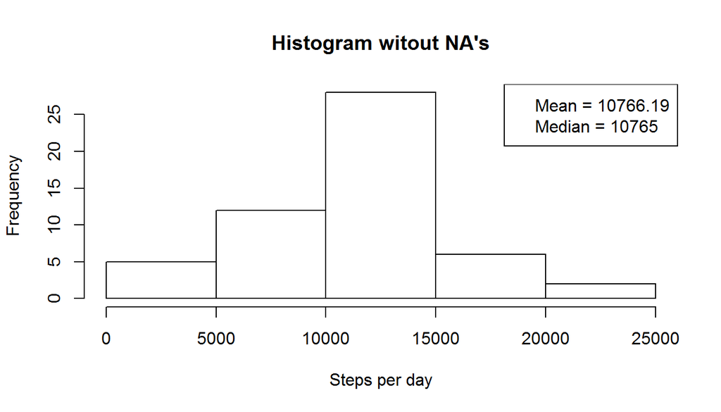

```r
ave <- round(mean(stepsPerDay$count),2)
med <- median(stepsPerDay$count)
hist(stepsPerDay$count, xlab="Steps per day", main="Histogram witout NA's")
legend("topright", c(paste("Mean =", ave),paste("Median =", med)))
```

## What is the average daily activity pattern?

Creating a time series plot of the 5-minute interval (x-axis) and the average number of steps taken, averaged across all days (y-axis).

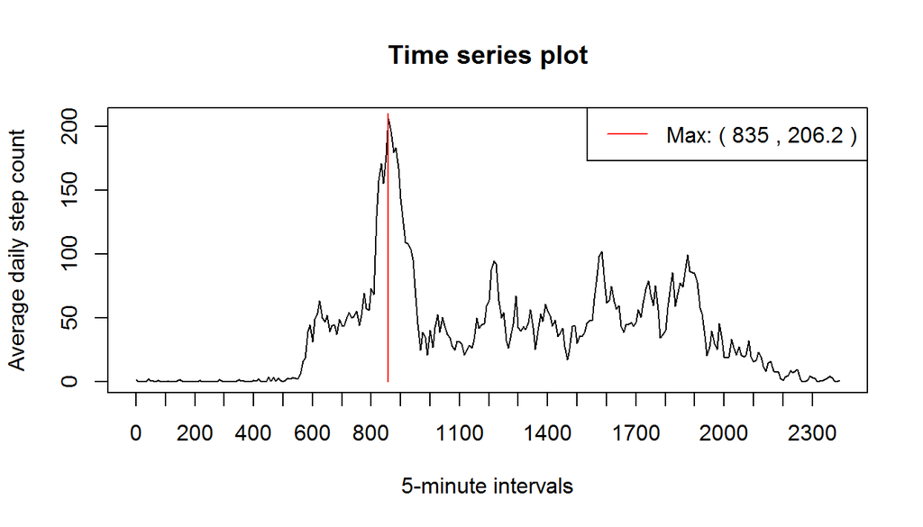

```r
nonNA$intervalExtra <- nonNA$interval
stepsPerInterval <- nonNA[,.(stepsSum = sum(steps), intervalCount = sum(!is.na(intervalExtra))),by=list(interval)][order(interval)]

stepsPerInterval$stepsPerInterval <- stepsPerInterval$stepsSum/stepsPerInterval$intervalCount

maxStepsInInterval <- with(stepsPerInterval, max(stepsPerInterval))
maxInterval <- with(stepsPerInterval, interval[stepsPerInterval==max(stepsPerInterval)])
maxIntervalIndex <- with(stepsPerInterval, sum(interval <= maxInterval))

plot(stepsPerInterval$stepsPerInterval, type="l", xaxt='n', main="Time series plot", xlab="5-minute intervals", ylab="Average daily step count")
atSeq <- seq(1, nrow(stepsPerInterval),by=12)
axis(1, at=atSeq, labels=stepsPerInterval$interval[atSeq])
lines(c(maxIntervalIndex, maxIntervalIndex),c(0, 210), col=2)
legend("topright", c(paste("Max: (", maxInterval, ",", round(maxStepsInInterval,1), ")")), col=2, lty=1)
```

The 5-minute interval, on average across all the days in the dataset, containing the maximum number of steps is interval 835.

## Imputing missing values

Calculating the total number of missing values in the dataset (i.e. the total number of rows with NAs).

```r
totalNumberNA <- sum(is.na(data$steps))
```

Total number of rows with NA’s is 2304.

### Strategy for filling in all of the missing values in the dataset:

*For each day-interval with missing value, we fill in average steps for this interval accros entire period. This is a simple good estimate.*

Create a new dataset that is equal to the original dataset but with the missing data filled in, according to deviced strategy.

```r
dataNA <- subset(data, is.na(steps))
setkey(dataNA, key=interval)
setkey(stepsPerInterval, key=interval)
dataNA <- merge(dataNA, stepsPerInterval, all.x=TRUE, all.y=FALSE)
dataNA$steps <- dataNA$stepsPerInterval
dataNA <- subset(dataNA, select=c(steps, date, interval))
nonNA <- subset(nonNA, select=c(steps, date, interval))
dataImp <- rbind(nonNA, dataNA)
dataImp <- dataImp[order(date,interval)]
```

Creating a histogram of the total number of steps taken each day with imputed values instead of NA’s.

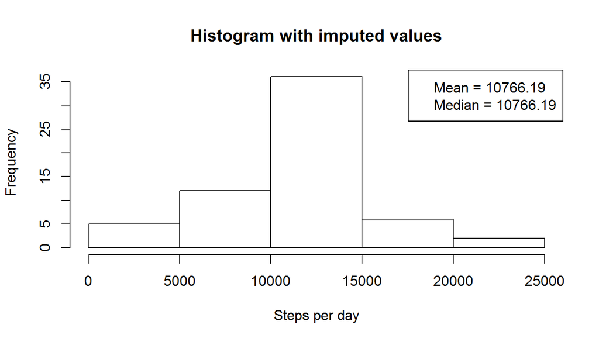

```r
stepsPerDayImp <- dataImp[,.(count = sum(steps)),by=list(date)]
ave <- round(mean(stepsPerDayImp$count),2)
med <- round(median(stepsPerDayImp$count),2)
hist(stepsPerDayImp$count, xlab="Steps per day", main="Histogram with imputed values")
legend("topright", c(paste("Mean =", ave),paste("Median =", med)))
```

## Are there differences in activity patterns between weekdays and weekends?

Creating a new factor variable with two levels, one for weekdays and one for weekends.

```r
dataImp <- as.data.frame(dataImp)
dataImp$date <- strptime(dataImp$date, "%Y-%m-%d")
dataImp$wd <- weekdays(dataImp$date)
dataImp$weekend <- dataImp$wd=="lørdag" | dataImp$wd=="søndag"
```

Creating a panel plot containing a time series plot of the 5-minute interval (x-axis) and the average number of steps taken, averaged across all weekday days or weekend days (y-axis).

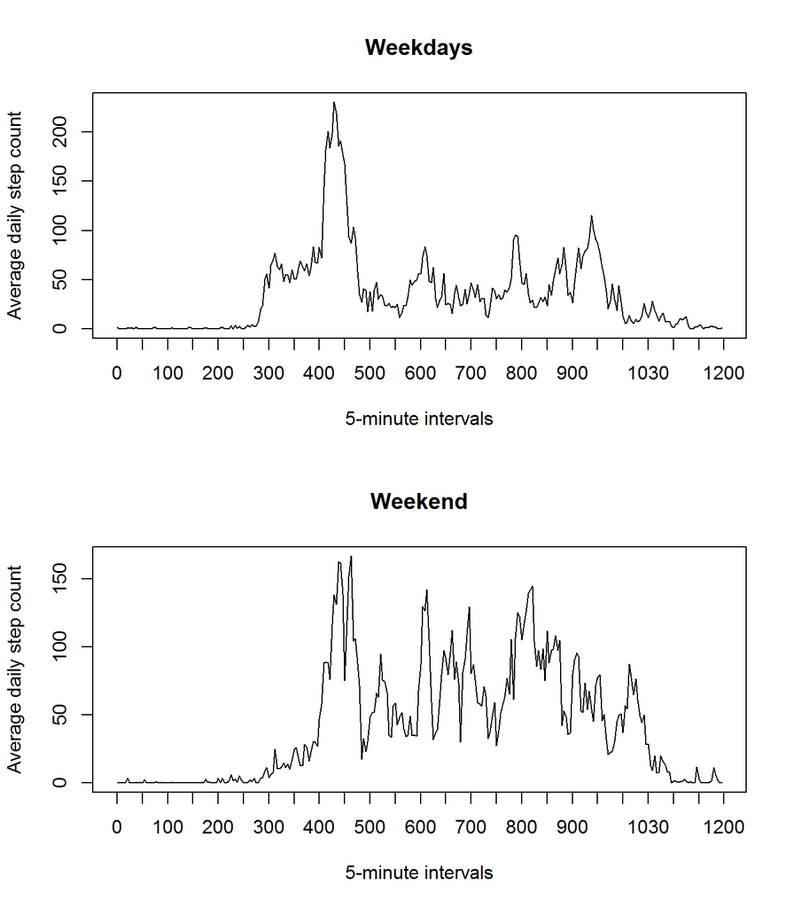

```r
dataImp <- as.data.table(dataImp)
dataImp$intervalExtra <- dataImp$interval

stepsPerIntDecomposed <- dataImp[,.(stepsSum = sum(steps), intervalCount = sum(!is.na(intervalExtra))),by=list(interval,weekend)][order(interval)]

stepsPerIntDecomposed$stepsPerInterval <- stepsPerIntDecomposed$stepsSum/stepsPerIntDecomposed$intervalCount

par(mfrow=c(2,1))
series <- c("Weekdays", "Weekend")
atSeq <- seq(1, nrow(stepsPerIntDecomposed),by=12)
for (i in 0:1) {
  plot(stepsPerIntDecomposed$stepsPerInterval[stepsPerIntDecomposed$weekend==i], type="l", xaxt='n', main=series[i+1], xlab="5-minute intervals", ylab="Average daily step count")
  axis(1, at=atSeq, labels=stepsPerIntDecomposed$interval[atSeq])
}
```

Above plots show that the weekday and weekend patterns differ, but the analysis stops here, so we won’t try to explain the differences. The difference indicate that the strategy for imputing missing values maybe could be improved by imputing different values for weekday and weekend intervals.